# Exercise Week 3: Solutions

ETC3550: 2021

```r
library(fpp3)
```

# fpp3 2.10, Ex 7

> The `aus_arrivals` data set comprises quarterly international arrivals (in thousands) to Australia from Japan, New Zealand, UK and the US. Use `autoplot()`, `gg_season()` and `gg_subseries()` to compare the differences between the arrivals from these four countries. Can you identify any unusual observations?

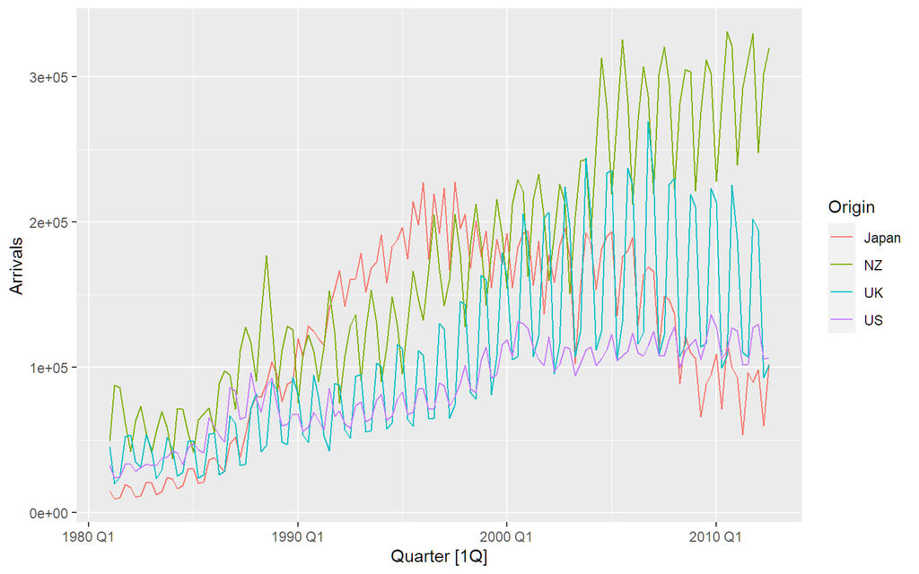

```r
aus_arrivals %>% autoplot(Arrivals)
```

Generally the number of arrivals to Australia is increasing over the entire series, with the exception of Japanese visitors which begin to decline after 1995. The series appear to have a seasonal pattern which varies proportionately to the number of arrivals. Interestingly, the number of visitors from NZ peaks sharply in 1988. The seasonal pattern from Japan appears to change substantially.

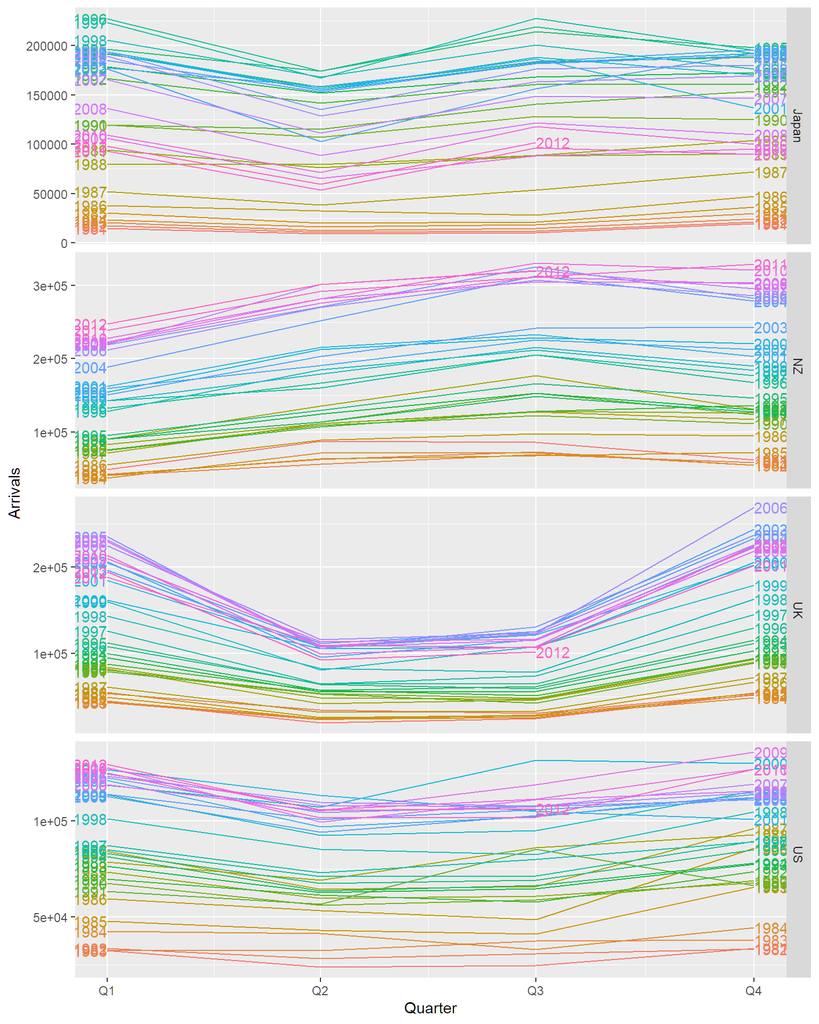

```r
aus_arrivals %>% gg_season(Arrivals, labels = "both")
```

The seasonal pattern of arrivals appears to vary between each country. In particular, arrivals from the UK appears to be lowest in Q2 and Q3, and increase substantially for Q4 and Q1. Whereas for NZ visitors, the lowest period of arrivals is in Q1, and highest in Q3. Similar variations can be seen for Japan and US.

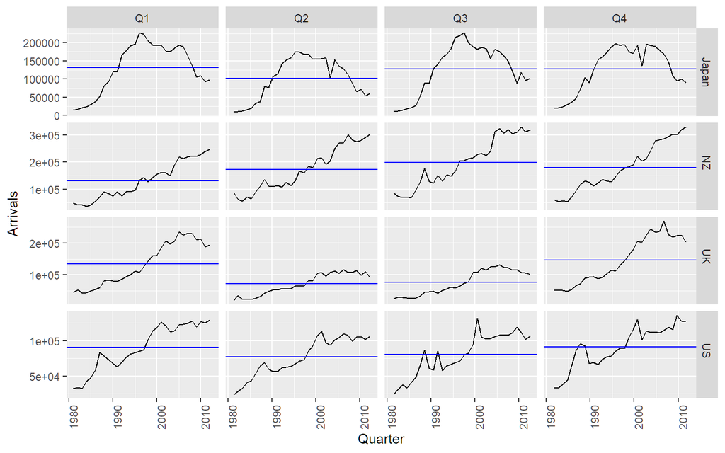

```r
aus_arrivals %>% gg_subseries(Arrivals)
```

Unusual observations:

- 2000 Q3: Spikes from the US (Sydney Olympics arrivals)
- 2001 Q3-Q4 are unusual for US (9/11 effect)
- 1991 Q3 is unusual for the US (Gulf war effect?)

# fpp3 2.10, Ex 8

> Monthly Australian retail data is provided in aus_retail. Select one of the time series as follows (but choose your own seed value):

> ```r
> set.seed(12345678)
> myseries <- aus_retail %>%
>   filter(`Series ID` == sample(aus_retail$`Series ID`,1))
> ```

> Explore your chosen retail time series using the following functions:

> ```r
> autoplot(), gg_season(), gg_subseries(), gg_lag(), ACF() %>% autoplot()
> ```

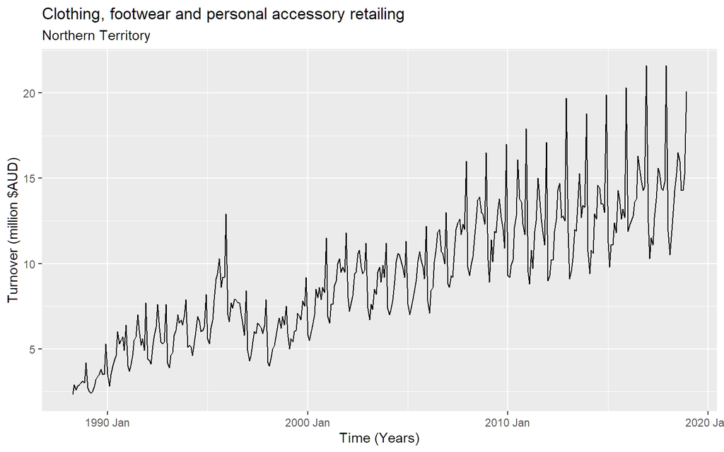

```r
set.seed(12345678)
myseries <- aus_retail %>%
  filter(`Series ID` == sample(aus_retail$`Series ID`,1))
myseries %>%
  autoplot(Turnover) +
  labs(y = "Turnover (million $AUD)", x = "Time (Years)",
       title = myseries$Industry[1],
       subtitle = myseries$State[1])
```

The data features a non-linear upward trend and a strong seasonal pattern. The variability in the data appears proportional to the amount of turnover (level of the series) over the time period.

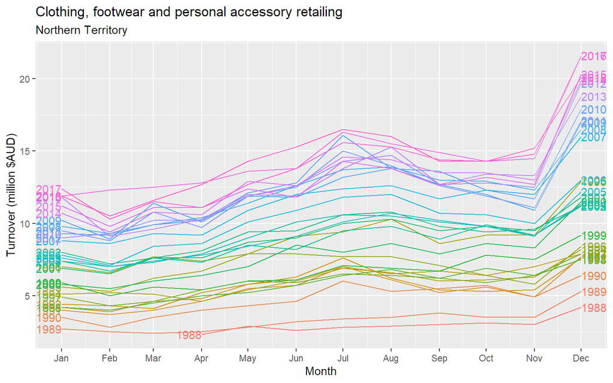

```r
myseries %>%
  gg_season(Turnover, labels = "both") +
  labs(y = "Turnover (million $AUD)",
       title = myseries$Industry[1],
       subtitle = myseries$State[1])
```

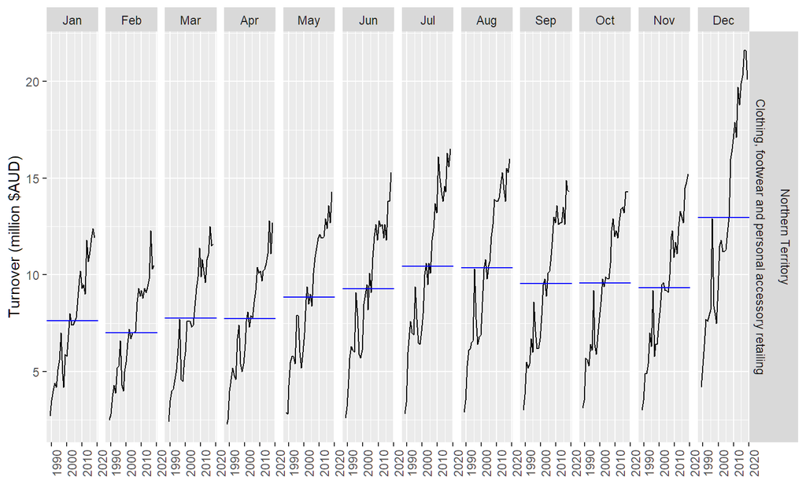

```r
myseries %>%
  gg_subseries(Turnover) +
  labs(y = "Turnover (million $AUD)", x="")
```

There is a strong trend in all months, with the largest trend in December and a larger increase in July and August than most other months.

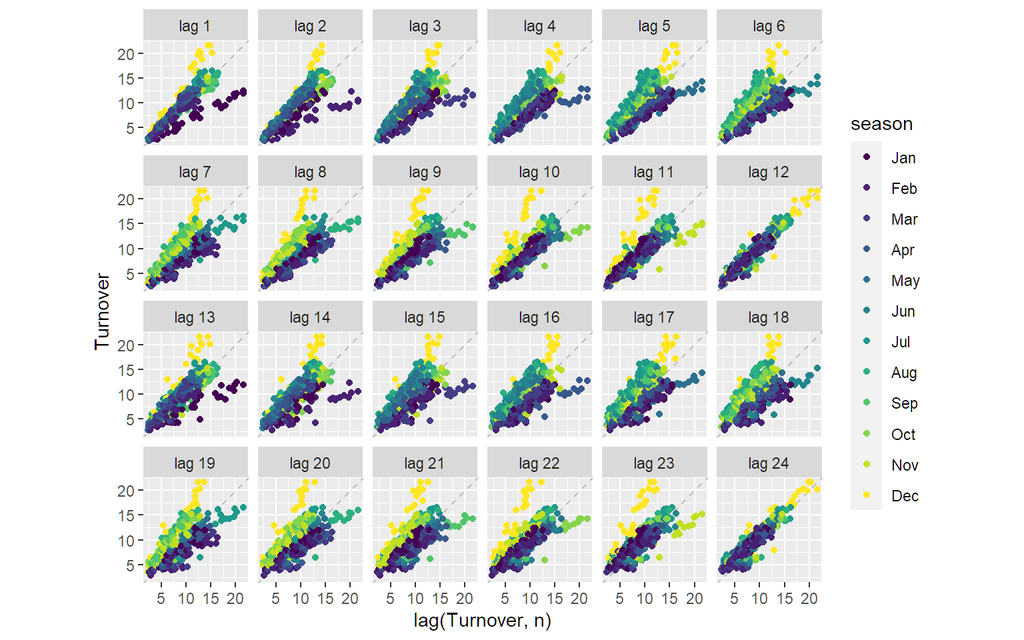

```r
myseries %>%
  gg_lag(Turnover, lags=1:24, geom='point') + facet_wrap(~ .lag, ncol=6)
```

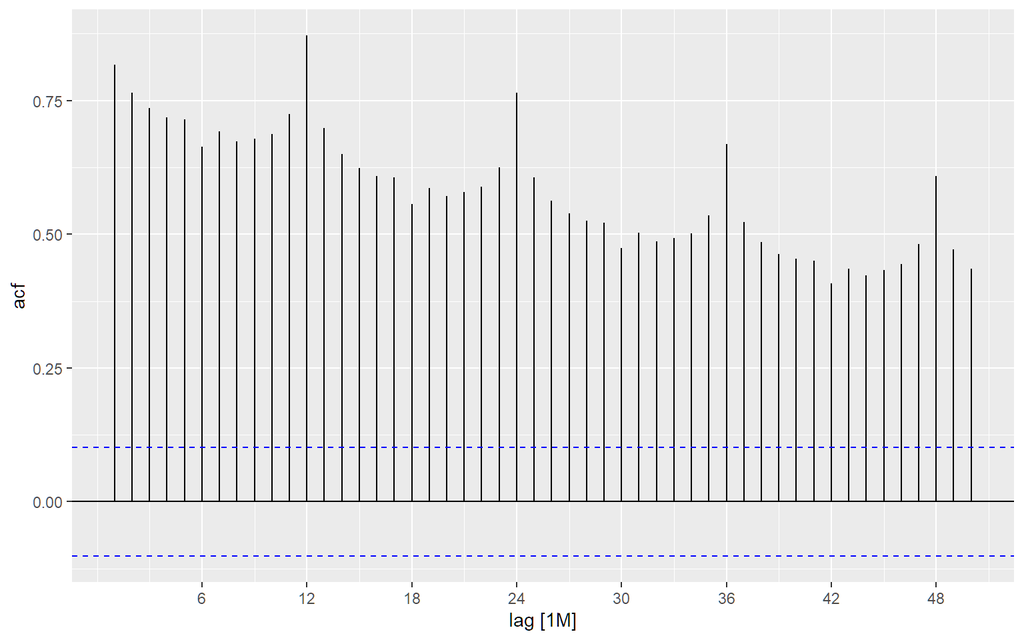

```r
myseries %>%
  ACF(Turnover, lag_max = 50) %>%
  autoplot()
```

# fpp3 2.10, Ex 9

> Use the following graphics functions: `autoplot()`, `gg_season()`, `gg_subseries()`, `gg_lag()`, `ACF()` and explore features from the following time series: “Total Private” `Employed` from `us_employment`, `Bricks` from `aus_production`, `Hare` from `pelt`, “H02” `Cost` from `PBS`, and `us_gasoline`.
> - Can you spot any seasonality, cyclicity and trend?
> - What do you learn about the series?
> - What can you say about the seasonal patterns?
> - Can you identify any unusual years?

## Total Private Employment in the US

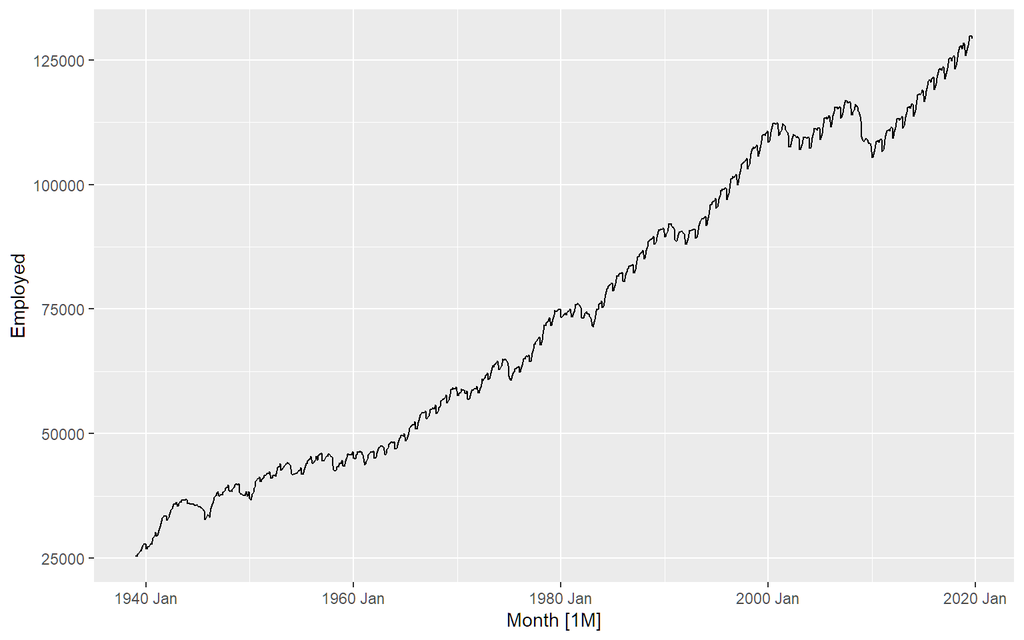

```r
us_employment %>%
  filter(Title == "Total Private") %>%
  autoplot(Employed)
```

There is a strong trend and seasonality. Some cyclic behaviour is seen, with a big drop due to the global financial crisis.

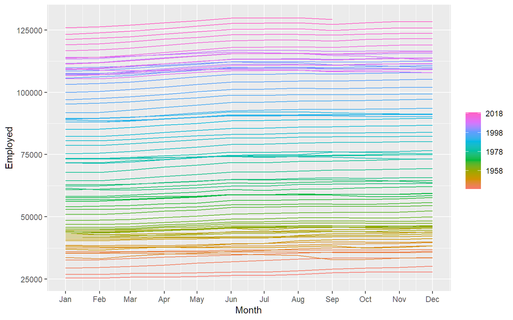

```r
us_employment %>%
  filter(Title == "Total Private") %>%
  gg_season(Employed)
```

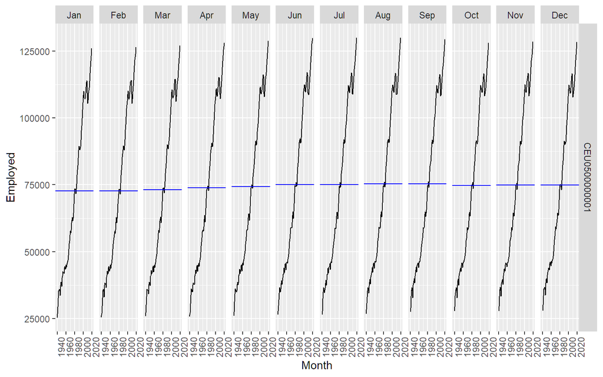

```r
us_employment %>%
  filter(Title == "Total Private") %>%
  gg_subseries(Employed)
```

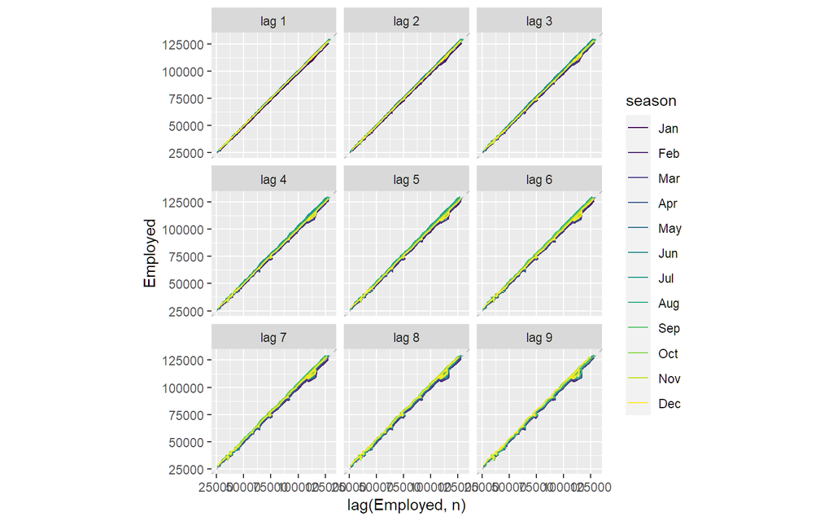

```r
us_employment %>%
  filter(Title == "Total Private") %>%
  gg_lag(Employed)
```

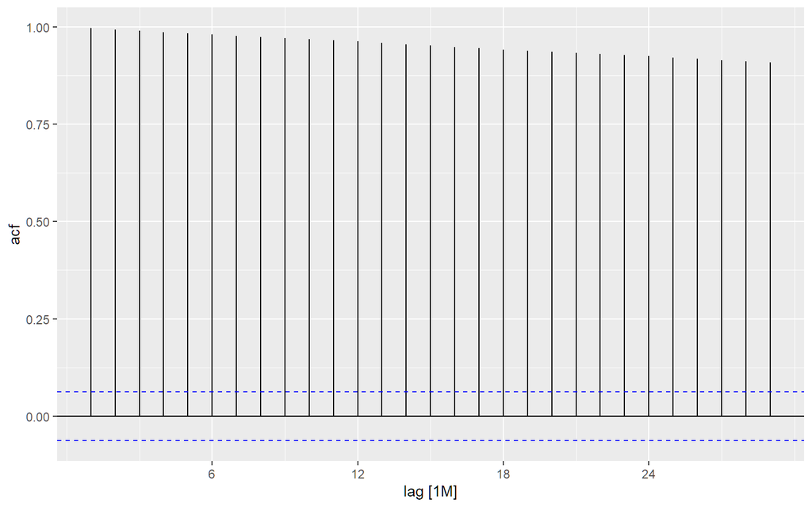

```r
us_employment %>%
  filter(Title == "Total Private") %>%
  ACF(Employed) %>%
  autoplot()
```

In all of these plots, the trend is so dominant that it is hard to see anything else. We need to remove the trend so we can explore the other features of the data.

## Brick production in Australia

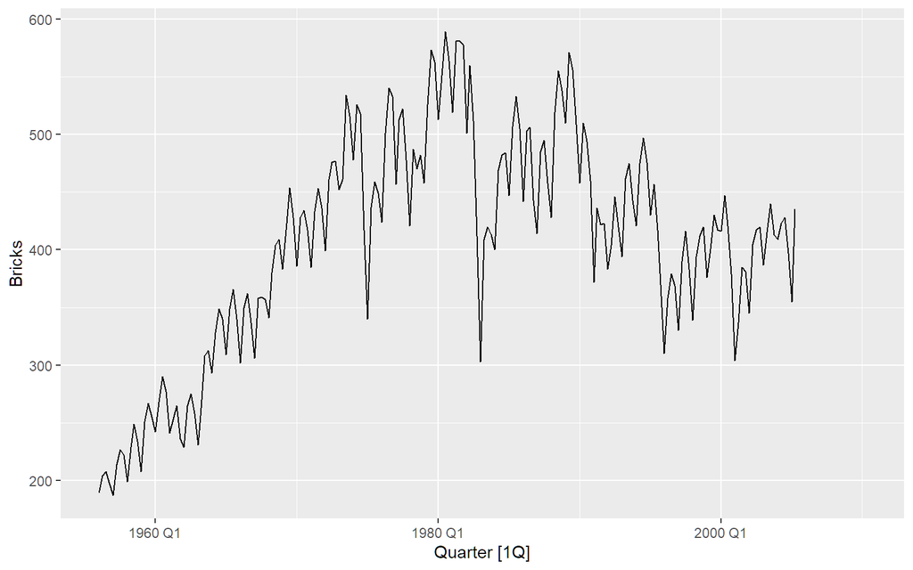

```r
aus_production %>%
  autoplot(Bricks)
```

A positive trend in the first 20 years, and a negative trend in the next 25 years. Strong quarterly seasonality, with some cyclicity – note the recessions in the 1970s and 1980s.

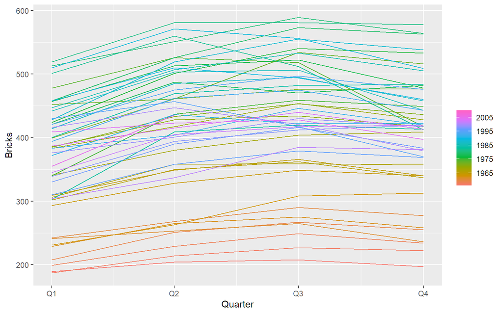

```r
aus_production %>%
  gg_season(Bricks)
```

Brick production tends to be lowest in the first quarter and peak in either quarter 2 or quarter 3.

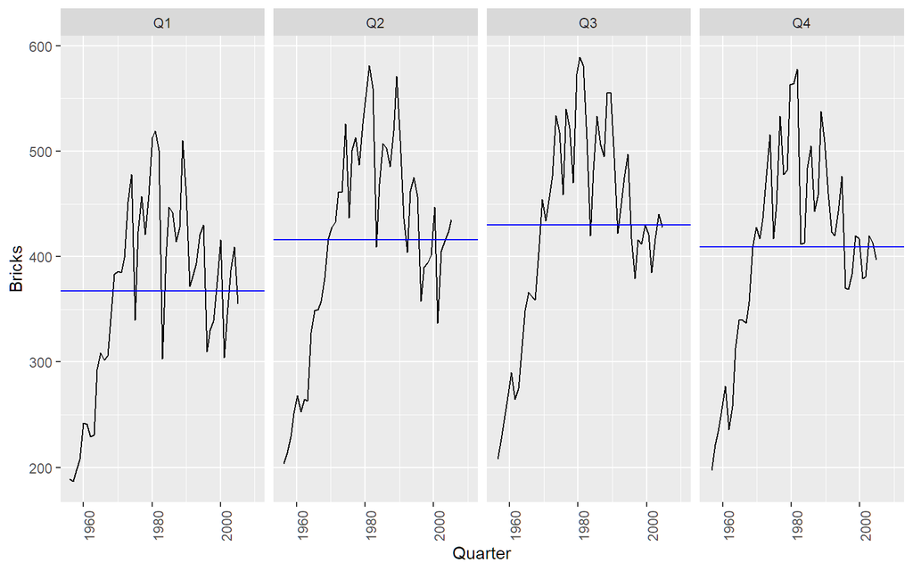

```r
aus_production %>%
  gg_subseries(Bricks)
```

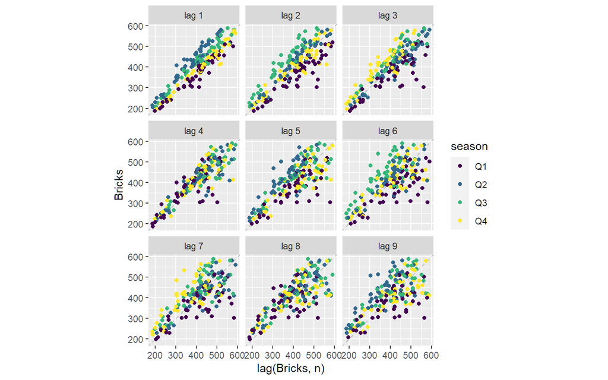

```r
aus_production %>%
  gg_lag(Bricks, geom='point')
```

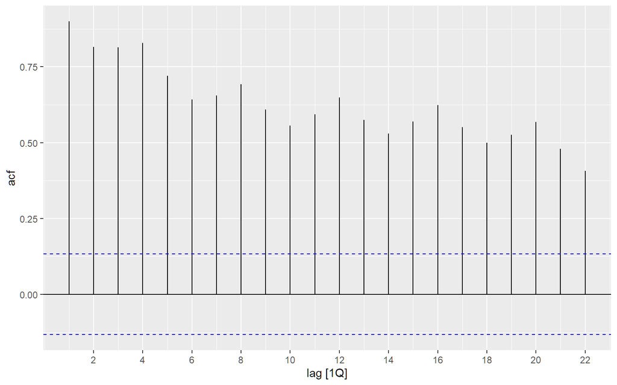

```r
aus_production %>%
  ACF(Bricks) %>% autoplot()
```

The seasonality shows up as peaks at lags 4, 8, 12, 16, 20, …. The trend is seen with the slow decline on the positive side.

## Snow hare trappings in Canada

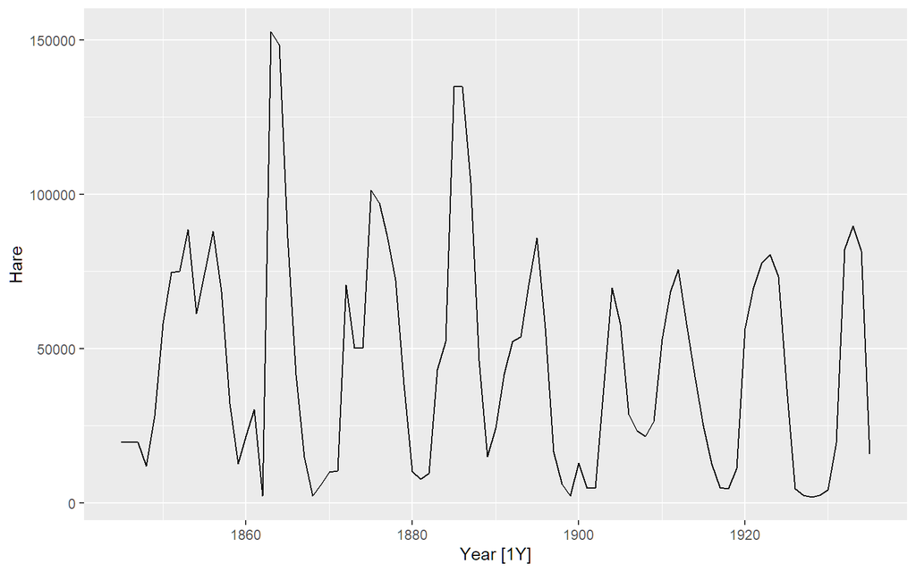

```r
pelt %>%
  autoplot(Hare)
```

There is some cyclic behaviour with substantial variation in the length of the period.

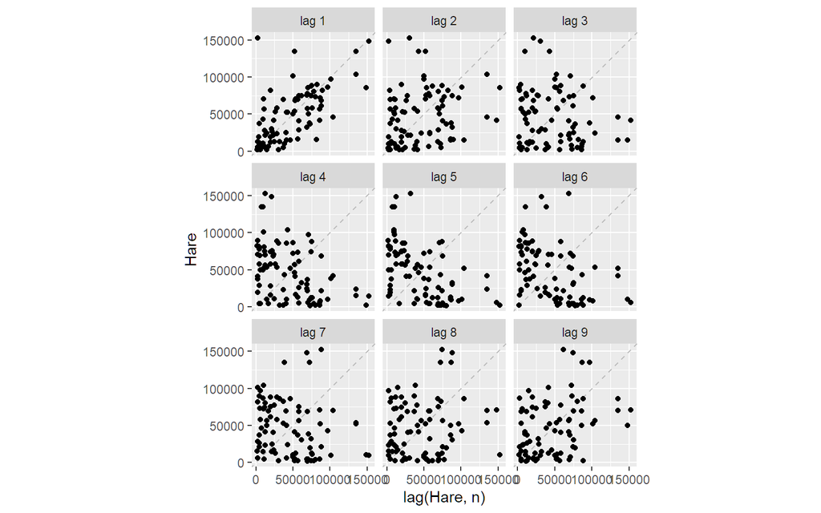

```r
pelt %>%
  gg_lag(Hare, geom='point')
```

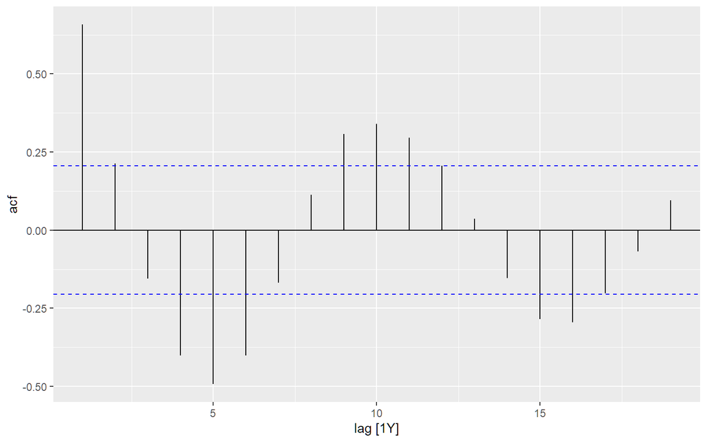

```r
pelt %>%
  ACF(Hare) %>% autoplot()
```

The cyclic period seems to have an average of about 10 (due to the local maximum in ACF at lag 10).

## H02 sales in Australia

There are four series corresponding to H02 sales, so we will add them together.

```r
h02 <- PBS %>%
  filter(ATC2 == "H02") %>%
  group_by(ATC2) %>%
  summarise(Cost = sum(Cost)) %>%
  ungroup()
```

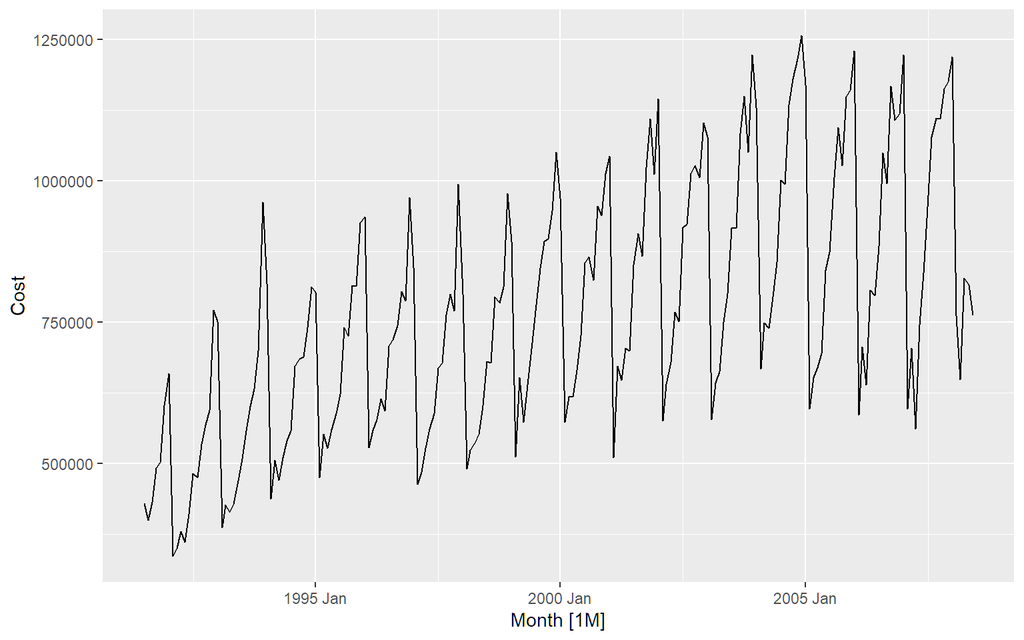

```r
h02 %>%
  autoplot(Cost)
```

A positive trend with strong monthly seasonality, dropping suddenly every February.

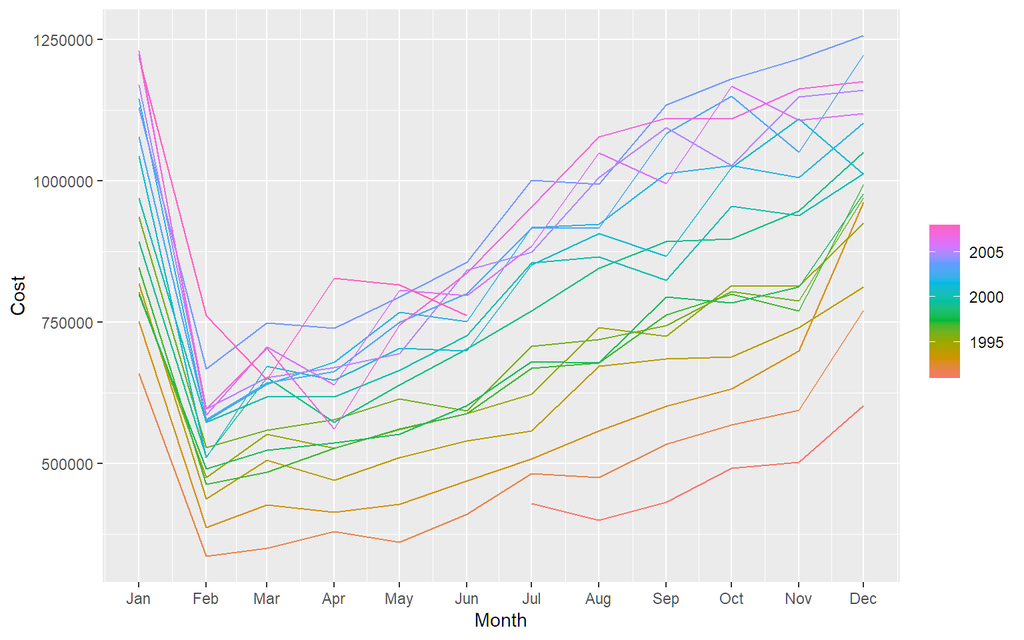

```r
h02 %>%
  gg_season(Cost)
```

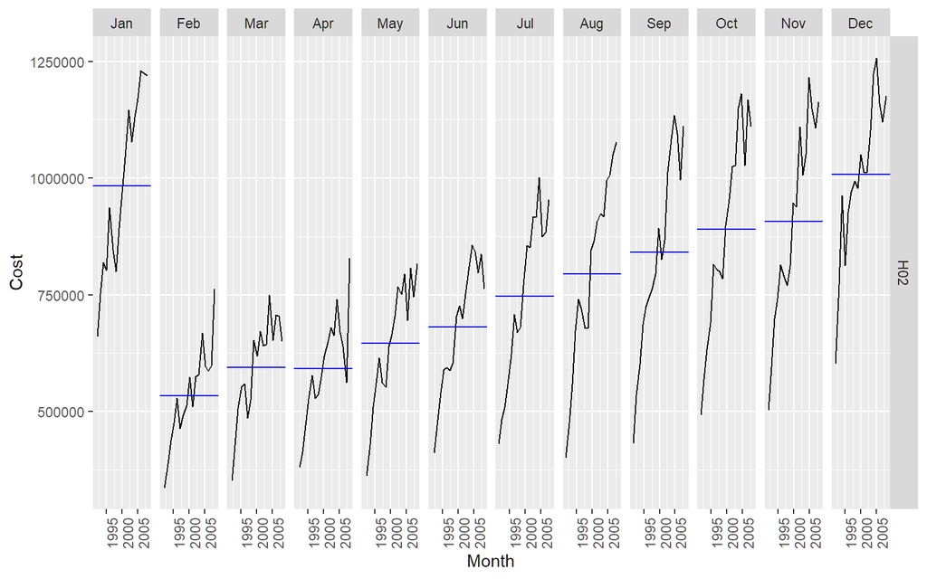

```r
h02 %>%
  gg_subseries(Cost)
```

The trends have been greater in the higher peaking months – this leads to increasing seasonal variation.

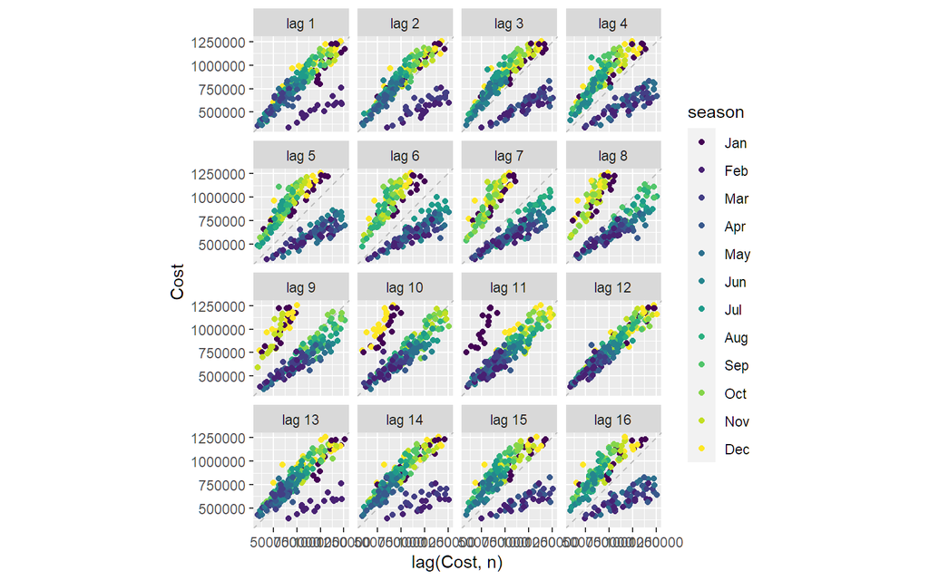

```r
h02 %>%
  gg_lag(Cost, geom='point', lags=1:16)
```

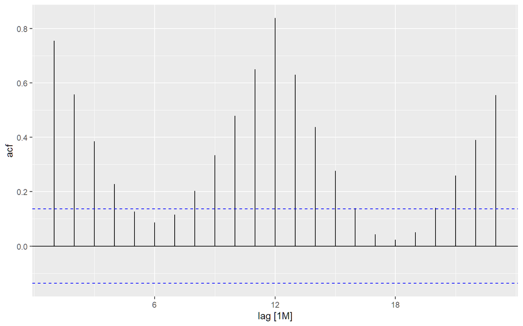

```r
h02 %>%
  ACF(Cost) %>% autoplot()
```

The large January sales show up as a separate cluster of points in the lag plots. The strong seasonality is clear in the ACF plot.

## US gasoline sales

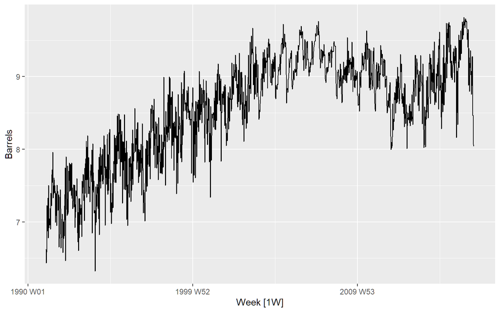

```r
us_gasoline %>%
  autoplot(Barrels)
```

A positive trend until 2008, and then the global financial crisis led to a drop in sales until 2012. The shape of the seasonality seems to have changed over time.

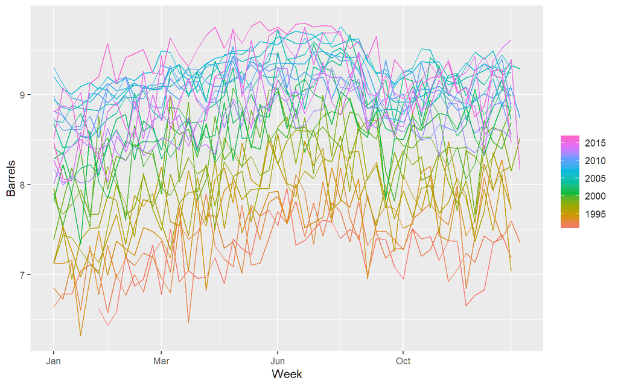

```r
us_gasoline %>%
  gg_season(Barrels)
```

There is a lot of noise making it hard to see the overall seasonal pattern. However, it seems to drop towards the end of quarter 4.

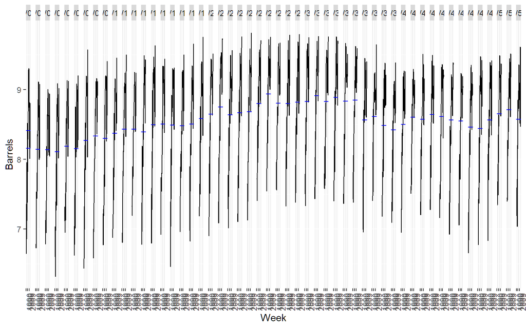

```r
us_gasoline %>%
  gg_subseries(Barrels)
```

The blue lines are helpful in seeing the average seasonal pattern.

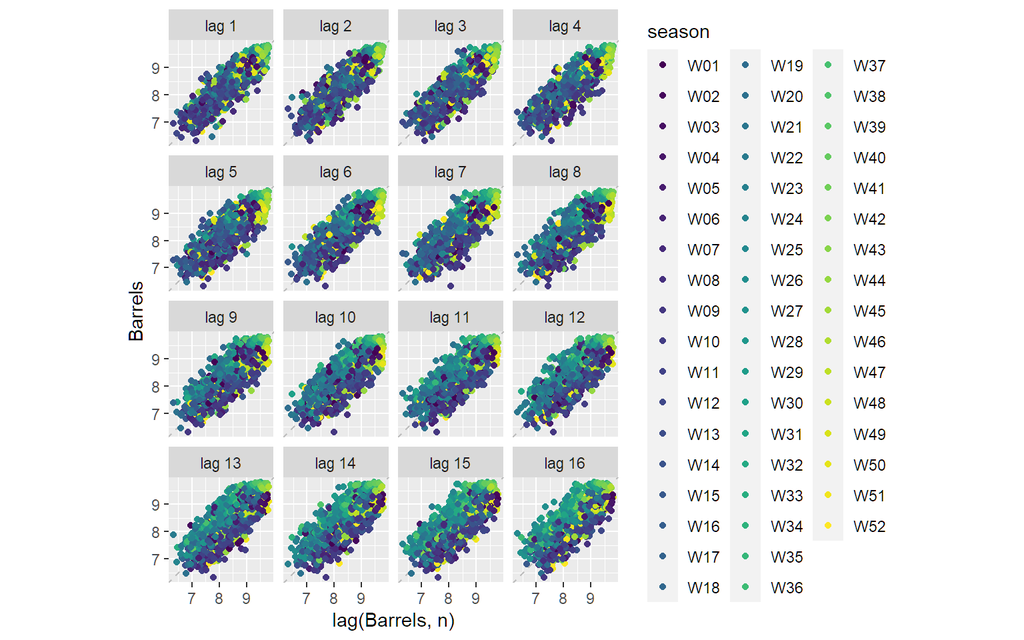

```r
us_gasoline %>%
  gg_lag(Barrels, geom='point', lags=1:16)
```

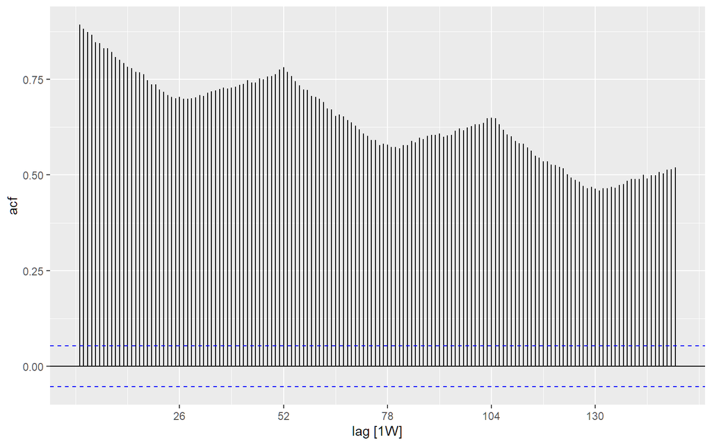

```r
us_gasoline %>%
  ACF(Barrels, lag_max = 150) %>% autoplot()
```

The seasonality is seen if we increase the lags to at least 2 years (approx 104 weeks)